# Il trovatore

Dramma lirico in vier Teilen (1853)

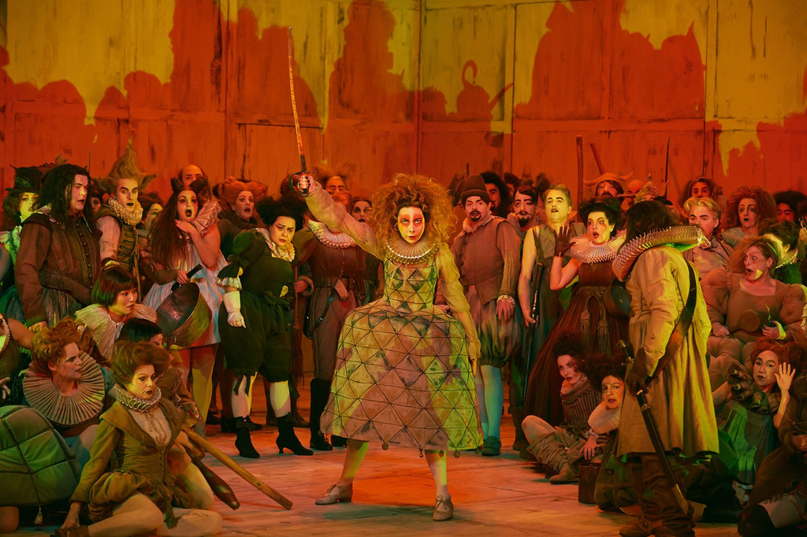

Azucena musste einst die Verbrennung ihrer Mutter als Hexe mit ansehen. Aus Rache entführte sie den jüngeren der beiden Söhne des dafür verantwortlichen alten Grafen Luna, warf dann aber – was niemand weiß – im Wahn irrtümlich nicht diesen, sondern den eigenen Sohn in die Flammen. Jahre später kämpfen der neue Graf Luna, der Bruder des Entführten, und der Troubadour Manrico, der vermeintliche Sohn Azucenas, nicht nur im Bürgerkrieg auf opponierenden Seiten, sondern geraten zudem auch aneinander, weil sie beide die Hofdame Leonora lieben. Niemand ahnt, dass Manrico in Wahrheit der entführte Bruder Lunas ist – bis Leonora sich selbst für den Geliebten opfert und der hasserfüllte Luna den Rivalen tötet.

Fasziniert von „den starken Situationen“, die sich aus dieser bizarren Handlungs- und Figurenkonstellation sowie aus der „Neuheit und Kühnheit des spanischen Dramas“ ergaben, schuf Giuseppe Verdi ein Werk voll hinreißender Belcanto-Nummern und elaboriert-dramatischem Orchesterpart, die wahre Begeisterungsstürme auslösten. Zwar erntete die sprunghafte und recht unglaubwürdige Handlung der Oper wohl nicht zu unrecht immer wieder Anlass für Kritik, doch boten die von Gräueltaten, Rachegelüsten, Wahn, Eifersucht, Liebe, Verzweiflung und Hass geprägten Szenen dem Komponisten Anlass zur Komposition äußerst ausdrucksstarker Melodien, emotionsgeladener Arien und effektvoller Chöre, die Il trovatore zu einem wahrhaft packenden Sängerfest machen.

Sonntag, 18. Mai 2025  
18.00 Uhr

[Staatsoper Unter den Linden](https://www.staatsoper-berlin.de/de/ihr-besuch/anfahrt/staatsoper-unter-den-linden.35/)

ausverkauft

Dauer: ca. 2:50 h inklusive einer Pause nach dem 2. Teil

Sprache: In italienischer Sprache mit deutschen und englischen Übertiteln

Altersempfehlung: ab 12 Jahren

## Besetzung

- Musikalische Leitung:

  [Alexander Soddy](https://www.staatsoper-berlin.de/de/kuenstler/alexander-soddy.1120/)
- Inszenierung:

  [Philipp Stölzl](https://www.staatsoper-berlin.de/de/kuenstler/philipp-stoelzl.1937/)
- Szenische Einstudierung:

  [Marcin Łakomicki](https://www.staatsoper-berlin.de/de/kuenstler/marcin-lakomicki.1324/)
- Co-Regie, Choreographie:

  [Mara Kurotschka](https://www.staatsoper-berlin.de/de/kuenstler/mara-kurotschka.1938/)
- Bühne:
  - [Conrad Moritz Reinhardt](https://www.staatsoper-berlin.de/de/kuenstler/conrad-moritz-reinhardt.1939/),
  - [Philipp Stölzl](https://www.staatsoper-berlin.de/de/kuenstler/philipp-stoelzl.1937/)
- Kostüme:

  [Ursula Kudrna](https://www.staatsoper-berlin.de/de/kuenstler/ursula-kudrna.1027/)
- Licht:

  [Olaf Freese](https://www.staatsoper-berlin.de/de/kuenstler/olaf-freese.1013/)
- Video:

  [fettFilm (Momme Hinrichs und Torge Møller)](https://www.staatsoper-berlin.de/de/kuenstler/fettfilm-momme-hinrichs-und-torge-moeller.1940/)
- Leonora:

  [Anna Netrebko](https://www.staatsoper-berlin.de/de/kuenstler/anna-netrebko.1516/)
- Inez:

  [Sandra Laagus](https://www.staatsoper-berlin.de/de/kuenstler/sandra-laagus.3488/)
- Graf von Luna:

  [George Petean](https://www.staatsoper-berlin.de/de/kuenstler/george-petean.2712/)
- Ferrando:

  [Riccardo Fassi](https://www.staatsoper-berlin.de/de/kuenstler/riccardo-fassi.2733/)
- Azucena:

  [Agnieszka Rehlis](https://www.staatsoper-berlin.de/de/kuenstler/agnieszka-rehlis.3507/)
- Manrico:

  [Yusif Eyvazov](https://www.staatsoper-berlin.de/de/kuenstler/yusif-eyvazov.1537/)
- Ruiz:

  [Sotiris Charalampous](https://www.staatsoper-berlin.de/de/kuenstler/sotiris-charalampous.2886/)
- - [Staatsopernchor](https://www.staatsoper-berlin.de/de/kuenstler/staatsopernchor.1020/),
  - [Staatskapelle Berlin](https://www.staatsoper-berlin.de/de/kuenstler/staatskapelle-berlin.1019/)